# BIOS 338/538 final exam

**Note**: About references

- Include references in the plain text window (rather than as a comment within R chunks)
  - Lack of adequate references (*where concepts are complex, and require searching around*) will be penalized with upto -5 points

## Points distribution

|  | 0 | Q1 | Q2 | Q3 | Q4 | sum |
| --- | --- | --- | --- | --- | --- | --- |
| Reg | - | 11 | 14 | 11 | 11 | 36 (*not 47*) |
| Bonus | - | 2 | 2 | 1 | - | 5 |

## **Important message:**

1. Answer question **Q2** first ;
2. Then **choose 2 out of the 3** remaining questions to answer (2 out of **Q1, Q3, Q4**)
3. Then spend time on the bonuses!

## 1. Describing, plotting, and interpreting data about MRI images of tumors (11 points + 2 bonus)

Concepts illustrated : *function -> vectorization, t-test and interpretation*

```r
library(tidyverse)
```

### 1.x. Load data (1 point)

load the `Tumor` dataset on your own by following these instructions

- Put the file in a separate data/ folder within in your Rproject (`.Rproj`) containing folder
- Load the `.csv` file using `relative path` starting from the folder this `.qmd` file is in
- Use `echo: true` in the chunk option below to show us the code in your final output

```r
Tumor_df <- read_csv('../../Data/Tumor.csv')
```

### 1.a. write 1-3 sentences describing the data (1 point)

Here’s where the data came from ([kaggle datasets](https://www.kaggle.com/datasets/jakeshbohaju/brain-tumor/data)) for context. *You may need to search the internet for some of the terms in order to explain them.*

url: https://www.kaggle.com/datasets/jakeshbohaju/brain-tumor/data

References: https://www.scirp.org/html/2-3400180_19553.htm#txtF3

### 1.b. Make scatterplots (3 points)

*Read full question 1.b. before answering!*

The goal here is to make three pairwise scatterplots of `Homogeneity`, `Energy` and `ASM`, `color`ed by whether the image was a `tumor` or not. You need to rename the legend to be more intuitive than 0 and 1.

Since the same commands need to be repeated multiple times, we will be more efficient and *try not to repeat code*. So

- Make a function to generate these 3 plots with less code repetition (1 point). The function should take in the x and y column names to be plotted. Calling this function thrice with these 3 different pairs of column pairs makes the 3 plots (*You can add more function arguments if they are useful).*
  - Reduce the transparency of the points so we can see overlapping points better
- (1 point) Call this function in a vectorized manner using `purrr::` package commands on the 3 pairs of vectors and stitch the images together using the `patchwork` package (using hints from `class21a_linreg-continued.qmd`), Now, collect the legends to show only a single legend for all 3 plots. (1 point)

NOTE:

1. You will need to change the binary variables to factors to get the proper scale.
2. *We chose these variables to plot out of many more in the dataset because they are on a similar scale.*

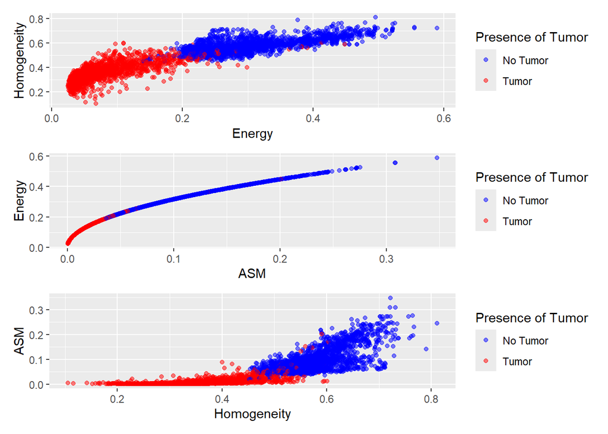

```r
tumor_pair <- function(y , x) {
  Tumor_df %>%
    ggplot(aes(x = .data[[x]], y = .data[[y]], colour = factor(Tumor))) +
    geom_point(alpha = 0.5) +
    labs(color = 'Presence of Tumor') +
    scale_color_manual(values = c('blue', 'red'), labels = c('No Tumor', 'Tumor'))
}

map2(c('Homogeneity','Energy','ASM'), c('Energy', 'ASM', 'Homogeneity'), ~ tumor_pair(.x, .y)) %>% patchwork::wrap_plots(ncol=1, nrow=3)
```

### 1.c.bonus. Plotting with scaling (2 points):

Try plotting Coarseness vs. Energy. Now plot again, but scale the variables. (1 point) Explain the significance of the `scale()` function and why it matters here (1 point)

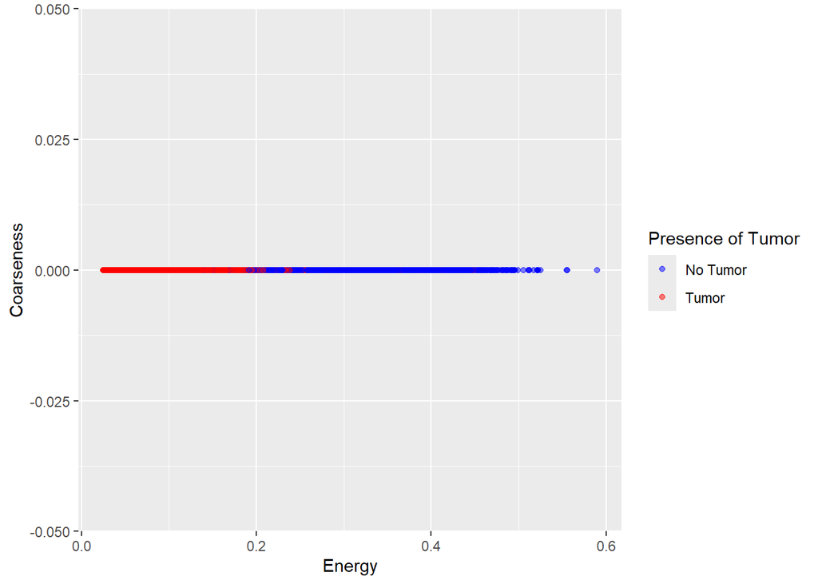

```r
tumor_pair('Coarseness', 'Energy')
```

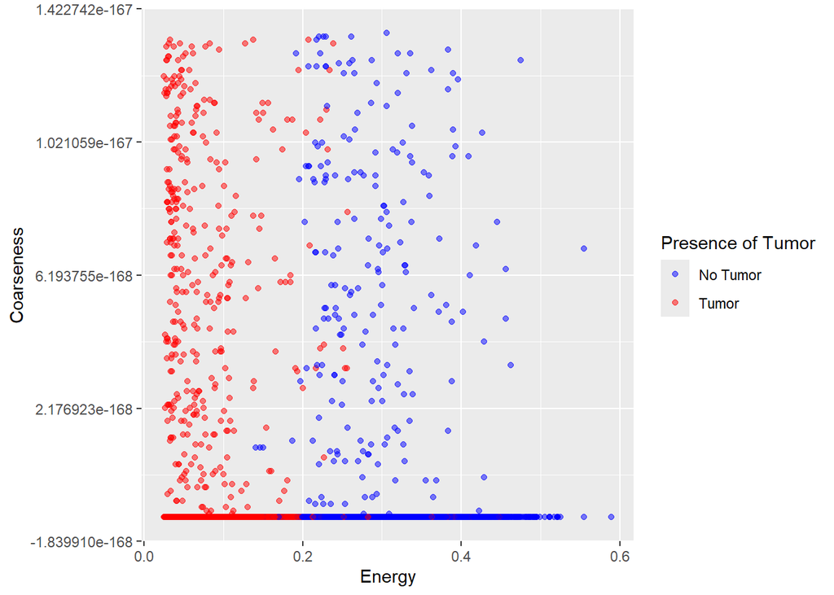

```r
Tumor_df %>%
  ggplot(aes(y = scale(Coarseness, center = TRUE, scale = FALSE), x = Energy, colour = factor(Tumor))) +
  geom_point(alpha = 0.5) +
  scale_color_manual(values = c('blue', 'red'), labels = c('No Tumor', 'Tumor')) +
  labs(color = 'Presence of Tumor', y = 'Coarseness')
```

The paired plot of Coarseness and Energy has to be scaled using `Scale()` because the values of the Coarseness are so small; without the `scale()` function, the graph is given as a straight line.

Reference: https://www.rdocumentation.org/packages/base/versions/3.6.2/topics/scale

### 1.d. Do any patterns seem to emerge in the data? (1 point)

The three observed features, ASM, Homogeneity, and Energy are all positively correlated.

### 1.e. t-tests for tumor vs non-tumor (3 points)

Now we are looking for columns in the dataset that vary between tumor and non-tumour samples using t-tests to attach statistical significance.

#### 1.e.1. Do the bottom 2 segments using a function / vectorization to minimize code repetition (1 point)

#### 1.e.2. do t-test and justify the tails (1 point)

Run three t.tests to look at **differences** between tumor and non-tumor images using the Energy, Homogeneity, and ASM variables. Note that tumor is the group variable!

Explain if the best choice here is to do a one-tailed t-test or a 2-tailed t-test and what in the question guides you to this choice. *Note that 2.a.1 & 2 walks through the technical difference between these t-tests so you don’t need to get into those here. Only need a brief answer here!*

```r
tumor_t <- function(variable) {

  no_tumor <- Tumor_df %>% filter(Tumor == 0) %>% pull({{variable}})
  tumor <- Tumor_df %>% filter(Tumor == 1) %>% pull({{variable}})

  t.test(no_tumor, tumor, alternative = 'greater')
}

map(c('ASM','Energy','Homogeneity'), ~ tumor_t(.x)) # Use map to apply t.test to each feature
```

```
[[1]]

    Welch Two Sample t-test

data:  no_tumor and tumor
t = 77.78, df = 2563.8, p-value < 2.2e-16
alternative hypothesis: true difference in means is greater than 0
95 percent confidence interval:
 0.08701458        Inf
sample estimates:
  mean of x   mean of y
0.098400483 0.009505311


[[2]]

    Welch Two Sample t-test

data:  no_tumor and tumor
t = 107.62, df = 3737.5, p-value < 2.2e-16
alternative hypothesis: true difference in means is greater than 0
95 percent confidence interval:
 0.2208963       Inf
sample estimates:
 mean of x  mean of y
0.30506135 0.08073568


[[3]]

    Welch Two Sample t-test

data:  no_tumor and tumor
t = 94.962, df = 3026, p-value < 2.2e-16
alternative hypothesis: true difference in means is greater than 0
95 percent confidence interval:
 0.2142519       Inf
sample estimates:
mean of x mean of y
0.5767914 0.3587619
```

It is more appropriate to use a one-tailed t-test in this case. Specifically, it is more useful to use a one-tailed test that tests for the upper critical value; this is because the scatterplots showed that the values for ASM, Homogeneity, and Energy were all higher in images with no tumors than in images with tumors.

#### 1.e.3. Add p-value onto plots (1 point)

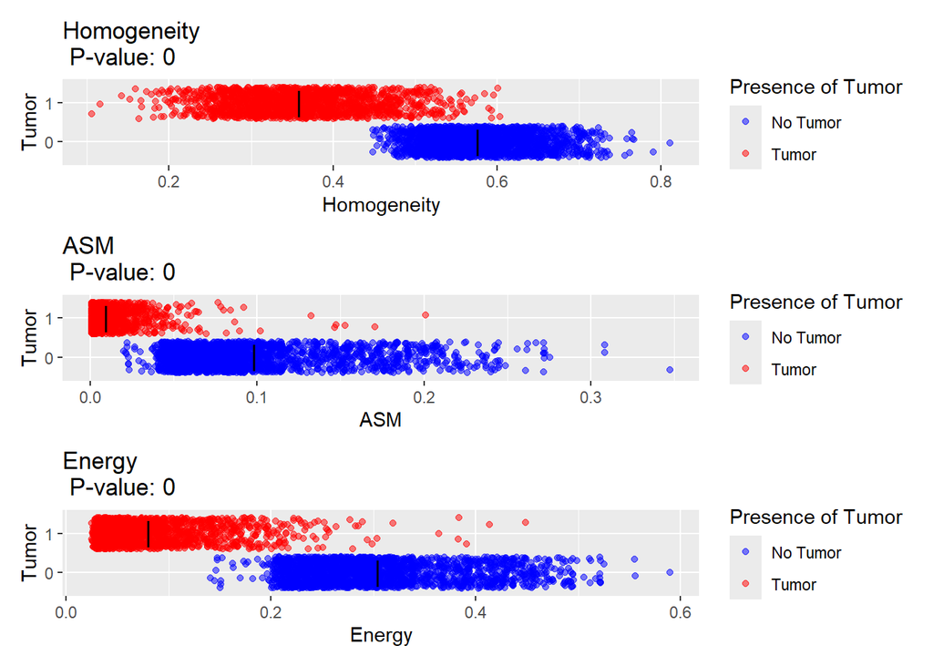

```r
tumor_p <- function(variable) {
  Tumor_df %>%
    ggplot(aes(x = .data[[variable]], y = factor(Tumor), colour = factor(Tumor))) +
    geom_jitter(alpha = 0.5) +
    stat_summary(fun = mean, geom = "point", shape = '|', size = 5, colour = 'black') +
    labs(title = paste(variable, "\n P-value:", round(tumor_t(variable)$p.value, 5)), color = "Presence of Tumor") +
    xlab(variable) +
    ylab('Tumor') +
    scale_color_manual(values = c('blue', 'red'), labels = c('No Tumor', 'Tumor'))
}

map(c('Homogeneity', 'ASM','Energy'), ~ tumor_p(.x)) %>% patchwork::wrap_plots(ncol=1, nrow=3)
```

### 1.f. Interpret results and reflect on future analysis ideas (2 points)

Interpret your results. How would you continue analyzing this data (no need to actually do it, but think about what else you could look at to better understand images with and without tumors (2 points)

In the results above, the p-value for each plot is extremely small and is rounded to 0, indicating that there is a strong statistical significance of the presence of a tumor on the observed features. We can further analyze this data by performing a PCA analysis to reduce the number of variables and noise. PCA will also help to identify which features are most responsible for the variances between tumorous and non tumorous traits.

Reference: https://builtin.com/data-science/step-step-explanation-principal-component-analysis

## 2. General statistics conceptual questions (14+2 points total)

### 2.a. Understanding of t-tests (10 points)

We will do a short exercise to demonstrate your understanding of t-tests, and specifically the difference between a *one-tailed (one-sided)* and *two-tailed* t-test.

#### 2.a.1. t-test part 1 (3 points)

You treated 10 patients with a medicine, 10 more with a placebo and measure their health score (0 to 1). What hypothesis test (*give full detailed name of the test*) would you do to show that the medicine group has a **higher** health score compared to the placebo group. (1 point)

- State in mathematical terms, what is the alternate hypothesis? (*hint: mentioned above in english)*
  - Example: *H*<sub>0</sub>: *μ*<sub>1</sub> = *μ*<sub>2 from wikipedia/[null hypothesis](https://en.wikipedia.org/wiki/Null_hypothesis#Basic_definitions)/basic definitions</sub>
- State in English and mathematical form, what is the **null hypothesis**?
- Is this a one tailed or two tailed test?

To show that the medicine group has a higher health score than the placebo group, I would use two-sample t-test.

Generate uniformly distributed data where the desired/theoretical means differ by *around* 0.3 for each of the two series above, print the data with the labels and demonstrate the `summary()` result of the correct t-test. Use `echo: true` so we can see your code in the report (2 points).

Note:

- The health scores should be strictly between 0 and 1
- There is some flexibility in how you can make the vectors here, all we want is their difference of means is 0.3
- You can make the medicine to have a higher mean than the placebo but the other way around is fine too for this illustration. The *actual data will never exactly have the difference of means of 0.3 exactly*

```r
group_medi <- runif(10, min = 0.7, max = 0.9)


group_placebo <- runif(10, min = 0.4, max = 0.6)


medi_data <- data.frame(
  group = rep(c("medicine", "placebo"), times = c(10,10)),
  score = c(group_medi, group_placebo)
)

t_medi <- t.test(score ~ group, data = medi_data, alternative = 'greater')

summary(t_medi)
```

```
            Length Class  Mode
statistic   1      -none- numeric
parameter   1      -none- numeric
p.value     1      -none- numeric
conf.int    2      -none- numeric
estimate    2      -none- numeric
null.value  1      -none- numeric
stderr      1      -none- numeric
alternative 1      -none- character
method      1      -none- character
data.name   1      -none- character
```

```r
t_medi
```

```
    Welch Two Sample t-test

data:  score by group
t = 10.23, df = 17.998, p-value = 3.147e-09
alternative hypothesis: true difference in means between group medicine and group placebo is greater than 0
95 percent confidence interval:
 0.2499873       Inf
sample estimates:
mean in group medicine  mean in group placebo
             0.8052637              0.5042522
```

**Bonus:** Show a scatter plot of these two datasets showing their mean and overlay the p-value from the t-test along with what the null hypothesis was on the plot. (2 points)

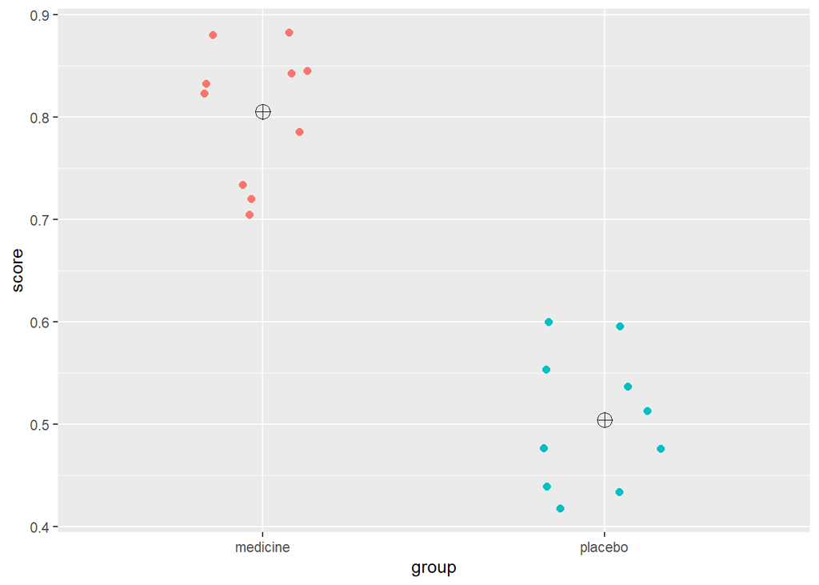

```r
# library(tidyverse)
ggplot(medi_data,aes(x = group, y = score, color = group)) +
  geom_jitter(width = 0.2, size = 2) +
  stat_summary(fun = mean, geom = "point", shape = 10, size = 4, color = 'black') +
  theme(legend.position = 'none')
```

#### 2.a.2. t-test part 2 (3 points)

In this variation, a co-worker remarked she is testing a different molecule and is unsure if it works like a medicine or toxin yet. So how would you change the test to account for either of these possibilities? (2 points)

- State, both in English and mathematical terms, what is the alternate hypothesis? (*hint: mentioned above in english)*
- State in English and mathematical form, what is the **null hypothesis**?
- Is this a one tailed or two tailed test?

This test would now be changed to be a two-tailed test. In the t-test, the upper critical limit would indicate that the medical scores of the medicine group is significantly greater than the placebo group, which would suggest that the molecule works as a medicine. On the other hand, the lower critical limit would indicate a significantly lower score for the medicine group suggesting a toxin-like mechanism.

- Alternate Hypothesis:
  - *H*<sub>a</sub>: *μ*<sub>1</sub> **≠** *μ*<sub>2</sub>
  - The health scores of the medicine and placebo group are not the same.
- Null Hypothesis:
  - *H*<sub>0</sub>: *μ*<sub>1</sub> = *μ*<sub>2</sub>
  - The health scores of medicine group and the placebo group are the same.
- This is a two-tailed test
- How would you modify the t-test for the same data above for this new test? (1 point)

```r
# Change the alternative argument to 'two.sided'
t_medi2 <- t.test(score ~ group, data = medi_data, alternative = 'two.sided')

t_medi2
```

```
    Welch Two Sample t-test

data:  score by group
t = 10.23, df = 17.998, p-value = 6.295e-09
alternative hypothesis: true difference in means between group medicine and group placebo is not equal to 0
95 percent confidence interval:
 0.2391925 0.3628305
sample estimates:
mean in group medicine  mean in group placebo
             0.8052637              0.5042522
```

#### 2.a.3. t-test part 3 (4 points)

You have a similar experiment now but the same 10 patients are monitored with placebo and medicine (2.a.1) over two different weeks; assume the dataset is ordered such that 1st patient in placebo group matches the first patient in medicine group. How will you modify the t-test to capture that there are not 2 independent samples of patients in this case? (1 point)

```r
# Pair the health scores of the medicine and placebo group
t_medi_paired <- t.test(score ~ group, data = medi_data, alternative = 'two.sided', paired = TRUE)

t_medi_paired
```

```
    Paired t-test

data:  score by group
t = 11.776, df = 9, p-value = 9.04e-07
alternative hypothesis: true mean difference is not equal to 0
95 percent confidence interval:
 0.2431868 0.3588363
sample estimates:
mean difference
      0.3010115
```

The paired argument in `t.test()` is set to `'FALSE'` by default, which specifies that the samples being compared are independent from each other. However, if you change the argument to read `'TRUE'`, the t-test will understand that the samples are not independent from one another and that the data come from the same individuals.

Show the above linked data as a graph with points of the same individual joined by a line (2 point2)

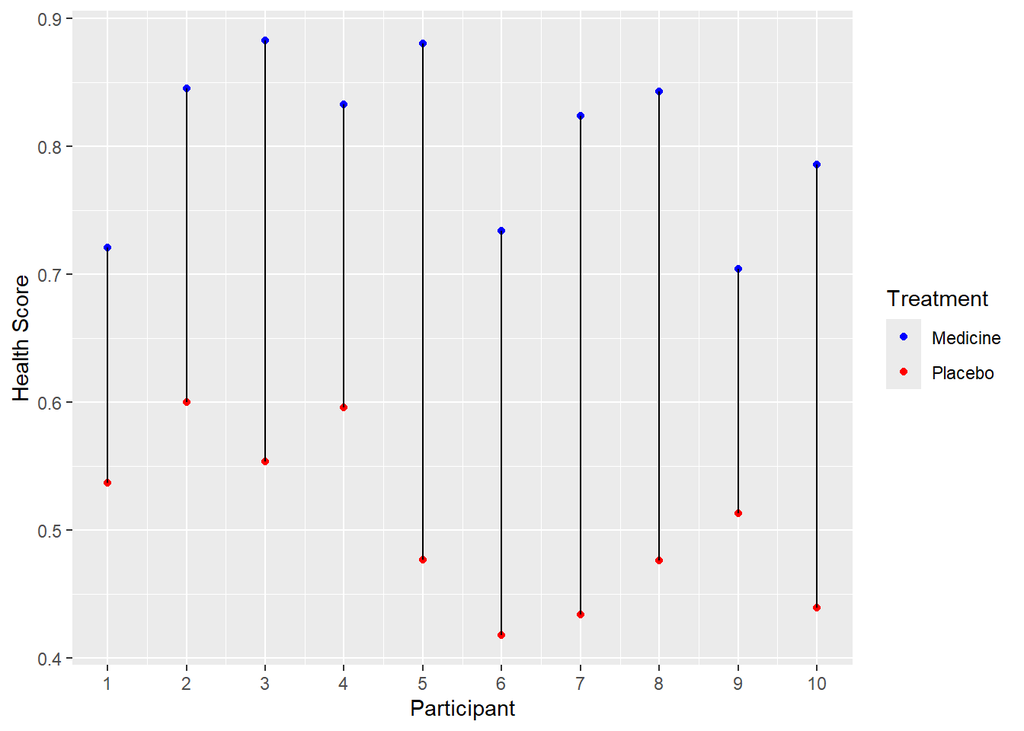

```r
medi_data_wide <- medi_data %>%
  group_by(group)

wider_data <- mutate(medi_data_wide, index = row_number()) %>%
  pivot_wider(names_from = group,
              values_from = score)

ggplot(wider_data,
       aes(x = index)) +
  geom_point(aes(y = medicine, colour = 'blue')) +
  geom_point(aes(y = placebo, colour = 'red')) +
  geom_segment(wider_data,
               mapping = aes(xend = index, y = medicine, yend = placebo)) +
  labs(x = "Participant", y = "Health Score", colour = 'Treatment') +
  scale_x_continuous(breaks = seq(0, 10, by = 1)) + # Set interval for x-axis
  scale_color_manual(values = c("blue", "red"), labels = c('Medicine', 'Placebo'))
```

References: https://stackoverflow.com/questions/37950511/set-tick-mark-intervals

https://stackoverflow.com/questions/61912689/draw-a-line-between-two-data-points-from-separate-variables-in-ggplot

Can you re-create the same t-test as above (and the same p-value) with a one-sample t-test? (1 point)

```r
diff <- group_medi - group_placebo

t.test(diff, mu = 0, alternative = 'two.sided')
```

```
    One Sample t-test

data:  diff
t = 11.776, df = 9, p-value = 9.04e-07
alternative hypothesis: true mean is not equal to 0
95 percent confidence interval:
 0.2431868 0.3588363
sample estimates:
mean of x
0.3010115
```

Reference: http://www.sthda.com/english/wiki/one-sample-t-test-in-r

### 2.b. Explain the meaning of p-value (2 points)

What is a p-value for hypothesis tests? What is one common mis-interpretation of p-value, elaborate why it is inaccurate. (2 points) See controversies here: [wiki](https://en.wikipedia.org/wiki/Misuse_of_p-values#:~:text=Misuse%20of%20p%2Dvalues%20is,with%20a%20specified%20statistical%20model.), [nature](https://www-nature-com.ezproxy.rice.edu/articles/nature.2016.19503),

The p-value is the probability that the difference in means of two samples is a result of chance; thus, the lower the p-value, the lower the chances that the observed difference in means of two mean values is a random occurrence and actually has significance.

A common misconception is that the p-value is the probability that the null hypothesis is true. This is inaccurate, as the null hypothesis simply states that the values of comparison are not significantly different. Rather, the p-value describes the probability that the actual effect of variable is as extreme as the observed effect. So, if the null hypothesis is *actually* true, then the p-value would be greater than the critical value (0.05).

Reference: https://en.wikipedia.org/wiki/Misuse_of_p-values

### 2.c. Know thy distribution (2 point)

- Why is it important to know the distribution of our data before continuing analysis? (0.5 point)

It is important to know the distribution of your data to ensure that you can conduct accurate data analysis. Some statistical tests are ground in the assumption that the data being analyzed is normally distributed; if your data is non-normally distributed such tests would yield inaccurate analyses.

Reference: https://machine-learning-made-simple.medium.com/why-you-should-analyze-the-distribution-of-your-data-695fd9f0f1be

- Which of the statistical concepts discussed in class assume certain distributions for the data, which distribution and briefly why do they need this assumption? (1.5 point)

The t-test assumes that the data being analyzed is normally distributed. T-tests are used to compare specific traits or characteristics which represent groups; when the data depicting these traits are normal, the mean become the representative measurement of the central tendency of the trait. The t-test also happens to compare the difference in true means of the data being analyzed, thus it is important that the data being analyzed is normally distributed, and the t-test assumes as much.

Reference: https://www.ncbi.nlm.nih.gov/pmc/articles/PMC6676026/#:~:text=The%20purpose%20of%20the%20t,essential%20in%20the%20t%2Dtest.

## 3. Working with Principal Component Analysis and iris plants (again!) (11+1 points total)

#### Bringing in the data. DO NOT EDIT!

##### 3.x. bonus (+1 point) : explaining purpose of each library in this script

3.x. bonus: (+1 bonus) : identify and note what each library is for (along with 1 function used from each)

1. The `corr` library is used to create data frames for correlation analysis.
2. The `ggfortify` library provides unified plotting tools to expand upon `ggplot2` (ie. PCA analysis tools).
3. The `dplyr` library “is a grammar of data manipulation, providing a consistent set of verbs that help you solve the most common data manipulation challenges”

References:

1. https://corrr.tidymodels.org/
2. https://cran.r-project.org/web/packages/ggfortify/index.html
3. https://dplyr.tidyverse.org/

```r
library(corrr)
library(ggfortify)
library(dplyr)

data(iris)
iris_data <- as_tibble(iris)
```

### 3.a. Write 1-3 sentences describing the data (1 point).

The iris dataset contains measurements of the Sepal Length, Sepal Width, Petal Width, and Petal Length of three species of iris flowers. Each species has 50 entries.

### 3.b. Correlations between the variables (2 point).

#### 3.b.1. Calculate correlations between the variables. (1 point)

*Hint. You need to exclude the species column*

```r
# hint
?correlate()
```

```
starting httpd help server ... done
```

```r
iris_corr <- iris_data[,-5] %>%
  correlate()
```

```
Correlation computed with
• Method: 'pearson'
• Missing treated using: 'pairwise.complete.obs'
```

```r
iris_corr
```

```
# A tibble: 4 × 5
  term         Sepal.Length Sepal.Width Petal.Length Petal.Width
  <chr>               <dbl>       <dbl>        <dbl>       <dbl>
1 Sepal.Length       NA          -0.118        0.872       0.818
2 Sepal.Width        -0.118      NA           -0.428      -0.366
3 Petal.Length        0.872      -0.428       NA           0.963
4 Petal.Width         0.818      -0.366        0.963      NA
```

#### 3.b.2. Are any of the variables highly correlated? (absolute value of the correlation >0.6) (1 point)

Sepal Length is highly correlated with Petal Length and Petal Width. Petal Length and Petal Width are also highly correlated.

### 3.c. Running PCA and analyzing (8 points)

#### 3.c.1. Generate the PCA (4 points)

Run a PCA analysis using the `prcomp()` function. Create a screeplot that shows the proportion of variance explained by each variable, a biplot of PC1 and PC2, and give a summary of the results with the `summary()` function

*Hint. Remember to scale the variables and remove species column!*

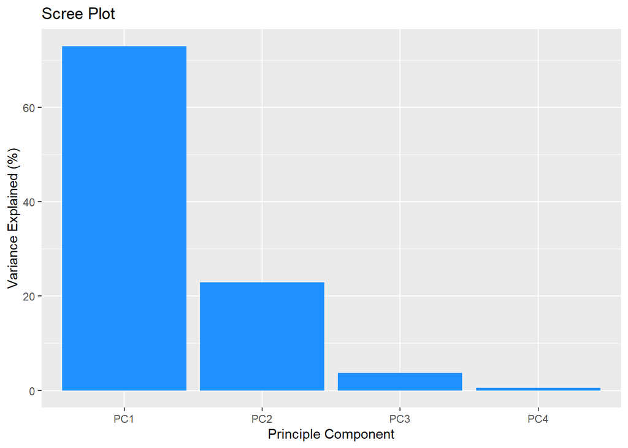

```r
# run this line to see documentation for the function
# ?prcomp()

# Run PCA
iris_pca <- iris_data[,-5] %>% prcomp(scale = TRUE)

# Find variance of each variable
iris_var <- iris_pca$sdev^2 / sum(iris_pca$sdev^2) # sdev is treated as the square root of the eigen values

iris_tib <- tibble(Group = c('PC1','PC2', 'PC3', 'PC4'), Value = iris_var * 100)

#Scree Plot
iris_splot <- iris_tib %>%
  ggplot(aes(y = Value, x = Group)) +
  geom_bar(stat = 'identity', fill = 'dodgerblue') +
  labs(title = 'Scree Plot',
       x = 'Principle Component',
       y = 'Variance Explained (%)')
iris_splot
```

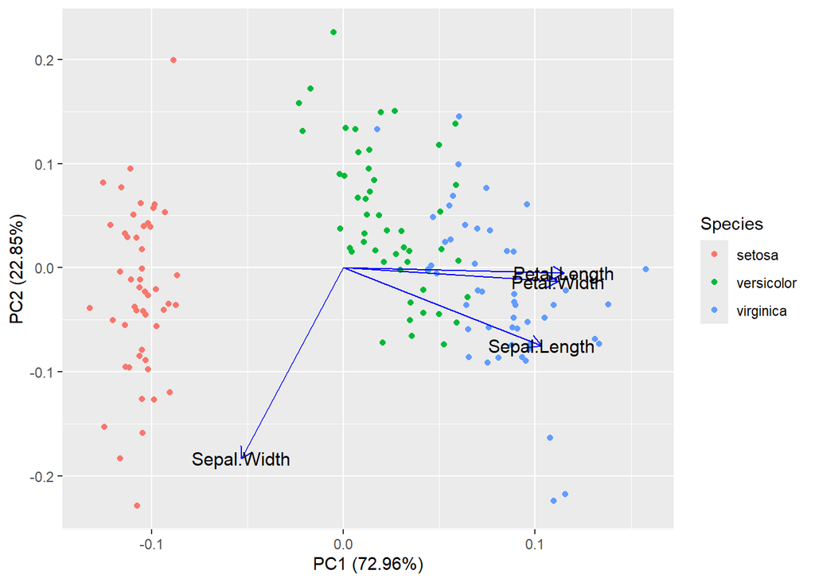

```r
#Biplot of PC1 and PC2
iris_bplot <- autoplot(iris_pca, data = iris, colour = 'Species',
                       loadings = TRUE,
                       loadings.colour = 'blue',
                       loadings.label = TRUE,
                       loadings.label.size = 4,
                       loadings.label.colour = 'black')
iris_bplot
```

```r
summary(iris_pca)
```

```
Importance of components:
                          PC1    PC2     PC3     PC4
Standard deviation     1.7084 0.9560 0.38309 0.14393
Proportion of Variance 0.7296 0.2285 0.03669 0.00518
Cumulative Proportion  0.7296 0.9581 0.99482 1.00000
```

Reference:

https://stats.stackexchange.com/questions/254592/calculating-pca-variance-explained

https://www.geeksforgeeks.org/how-to-make-scree-plot-in-r-with-ggplot2/

https://cran.r-project.org/web/packages/ggfortify/vignettes/plot_pca.html

#### 3.c.2. Better plots with `autoplot()` (1 point)

Now, use the function `autoplot()` from `ggfortify` package to better view the results of the biplot. Be sure to include the loadings.

*Hint: You need to search for how to add loadings to this!*

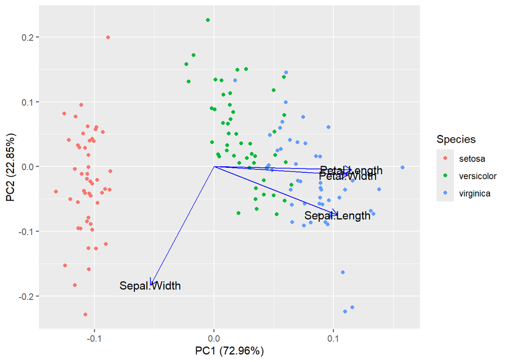

```r
# Same as the biplot from 3.c.1
iris_bplot <- autoplot(iris_pca, data = iris, colour = 'Species',
                       loadings = TRUE,
                       loadings.colour = 'blue',
                       loadings.label = TRUE,
                       loadings.label.size = 4,
                       loadings.label.colour = 'black')
iris_bplot
```

## 4. Analyzing housing data (11 points)

### 4.a. Loading data (1 point)

load the `housing_Final_Exam` dataset on your own, similar to the tumor data

- Put the file in a separate data/ folder in your Rproject folder
- Load the `.csv` file using `relative path` starting from the folder this `.qmd` file is in

Here’s where the data came from ([kaggle datasets](https://www.kaggle.com/datasets/iamsouravbanerjee/house-rent-prediction-dataset)) for context. *You may need to search the internet to understand some of the terms.*

url: https://www.kaggle.com/datasets/iamsouravbanerjee/house-rent-prediction-dataset

```r
# housing <- read.csv('PATH_HERE')
```

(1 point) First take a look at the data! Look at all the columns and try to understand what they mean. Now, create a new column called ‘price_per_area’ that contains the price divided by the square footage of the house. Plot this new column as a histogram and describe it’s relationship.

For our future plots, it may get confusing to have such larger numbers for our y axis. To simplify this, divide the sales price by a thousand with a new column called ‘price_thousands’.

### 4.b. Data Investigation (3 points total)

Create three plots to investigate the relationship between *a different variable* and *house price*. One plot must be for a numeric variable and two for categorical variables. For the two categorical variables one must be a binary categorical variable. *Consider this carefully!* **Describe the relationship you see for each. All columns except price and area should be treated as factors! Properly label all axises along with the units!**

Axis labels should be like this with the units in the bracket: `length (cm)`

### 4.c. Simple linear regression model (3 points)

Now you want to create the optimal model possible! You are confident that area is going to have the largest effect on sales price. Create a univariate linear regression model for `price_thousands` and `area`. Check to make sure the data meets the assumptions for linear regression. Show the output from the model.

- **Describe the null and alternative hypothesis**
- **Determine if we should accept or reject it.**
- **Describe the relationship of the model (i.e. strong, weak, negative…)**
- **Interpret the model that is produced. What are the coefficients and how do we interpret them?**

**Null:**

**Alternative:**

**Accept or Reject:**

**Relationship:**

**Interpretation of Model:**

### 4.d. multivariate modelling (4 point)

#### 4.d.1. Choosing variables for multivariate linear regression (1 point)

Now that you are confident that area plays a significant role in affect a houses price, what are other variables that are important? To maintain the independency assumption of linear regression, we want to use variables that won’t be directly correlated with area. What are some variables that are likely strongly correlated with area? **Explain your reasoning.**

Answer:

#### 4.d.2. Multivariate modelling (3 point)

Add one of the variables that **is not correlated with area to your model.** Create a second linear regression model and once again show it’s output.

- **Describe the null and alternative hypothesis**
- **Determine if we should accept or reject it.**
- **Describe the relationship of the model (i.e. strong, weak, negative…)**
- **Interpret the model that is produced. What are the coefficients and how do we interpret them?**

**Null:**

**Alternative:**

**Accept or Reject:**

**Relationship:**

**Interpretation of Model:**

# Attributions

## Questions

For the questions, I would like to acknowledge these sources of inspiration

- Annie and Sam for making all these creative questions
- Nice list of [css colours](https://duckduckgo.com/?t=ffab&q=css+colours&ia=answer&iax=answer) to format a `.class` of text in a particular colour to distinguish it from questions (*if you are curious, you can change the colour of all your answers from firebrick to something else by doing* `find-and-replace` in the `Source` mode! **+1 bonus point** for this)

## Solutions

Collaborations with groupmates: Seungheon Lee and Gary Shi

Space for TA/grader comments here!

(copy this in the middle of the code for more elaborate comments)